# Electro Dunas — Elasticidad-ingreso de la demanda y proyección de volúmenes

Estimación reproducible con data abierta (frecuencia anual)

2026-10-07 17:23 UTC

# Resumen ejecutivo

Con **n = 8 observaciones anuales (2018–2025)** y el VAB real de Ica como driver:

## 1. El volumen de ELDU no lo mueve principalmente el ingreso

La energía distribuida creció **4.17%/año** entre 2018 y 2025. Esa cifra se parte en dos:

| Componente | CAGR |
| --- | --- |
| Clientes (conexiones nuevas) | **2.65%** |
| Energía por cliente | **1.52%** |
| **Total energía** | **4.17%** |
| *(driver)* VAB real de Ica | *3.94%* |

Las **conexiones explican 64%** del crecimiento del volumen. Eso cambia el modelo: una elasticidad-ingreso única no es el driver dominante, y meterle todo el crecimiento adentro la infla. Por eso η se estima sobre el **consumo por cliente** y el crecimiento de clientes se proyecta aparte.

## 2. La elasticidad-ingreso estimada

> **η ∈ [0.11 , 0.53]** aplicada al **consumo por cliente**. Se entrega como **rango, no como punto**: eta varía 0.16 entre especificaciones razonables (umbral 0.15): la incertidumbre es de especificación. El IC 95% de muestreo de la especificación principal es [0.110, 0.529].

Especificación principal: OLS en diferencias sobre energía POR CLIENTE, HAC Newey-West. Motivo: n=8 < 12: en niveles la separación ingreso/tendencia es frágil, así que se reporta la de DIFERENCIAS y los niveles quedan como corroboración.

## 3. Contraste con el supuesto vigente del DCF

El DCF usa **η = 0.80 (BT) y 0.90 (MT)**. Frente al rango estimado [0.11, 0.53]: **ambos quedan muy por encima.**

Pero el problema de fondo **no es el número, es la fórmula.** La regla `Q(1+η·g)` no tiene término de conexiones, así que asume que el volumen sólo crece si crece el ingreso. Con esta data:

| Regla de proyección | CAGR implícito |
| --- | --- |
| Observado 2018–2025 | **4.17%** |
| Dos términos (clientes + η por cliente) | **3.91%** |
| Una sola elasticidad, sin clientes | 1.26% |
| Supuesto DCF (η≈0.85), sin clientes | 3.35% |

Leído así, el 0.8/0.9 del DCF **acierta de casualidad**: es un número inflado que compensa un término de conexiones que falta. Da un resultado parecido al histórico por la razón equivocada, y dejaría de funcionar en cuanto el ritmo de conexiones cambie — que es precisamente lo que una valorización a 10 años necesita poder mover.

**Recomendación:** reemplazar la elasticidad única por los dos términos, con η en el rango estimado aplicado al consumo por cliente, y el crecimiento de conexiones como supuesto explícito del comité.

# Fuentes utilizadas

| Archivo | Descripción | Registrado (UTC) |
| --- | --- | --- |
| data/raw/eldu_demanda_memorias.csv | Electro Dunas — demanda y clientes por año, compilado de las Memorias Anuales | 2026-10-07 17:23:40 |
| data/raw/eldu_energia_anual.csv | Serie anual canónica de ELDU (variable: dist_eld_gwh) | 2026-10-07 17:23:40 |
| data/raw/bcrp_pbi_nacional_yoy.csv | BCRP — PBI nacional, variación % interanual (mensual) | 2026-10-07 17:23:40 |
| data/raw/bcrp_ipc_lima.csv | BCRP — IPC Lima Metropolitana (Dic.2021 = 100) | 2026-10-07 17:23:40 |
| data/raw/bcrp_tc_venta.csv | BCRP — Tipo de cambio interbancario venta (S/ por US$), diario | 2026-10-07 17:23:40 |
| data/raw/inei_vab_ica.xlsx | INEI — VAB de Ica por años y actividad, precios constantes | 2026-10-07 17:23:41 |

**Procedencia de cada variable del panel:**

- `bcrp_pbi_nacional_yoy`: BCRP PN01728AM — PBI nacional, variación % interanual (mensual) [driver_alternativo]
- `bcrp_ipc_lima`: BCRP PN38705PM — IPC Lima Metropolitana (Dic.2021 = 100) [control]
- `bcrp_tc_venta`: BCRP PD04638PD — Tipo de cambio interbancario venta (S/ por US$), diario [control]
- `income`: INEI — Valor Agregado Bruto real de Ica, precios constantes (archivo=inei_vab_ica.xlsx; hoja=cuadro1; fila_anios=7; fila_total=21; rotulo=‘Valor Agregado Bruto’)
- `energia_gwh`: Energía ELDU (GWh/año) — CSV curado por el usuario (data/raw/eldu_energia_anual.csv)
- `energia_gwh`: variable de volumen elegida = **dist_eld_gwh**

IPC y tipo de cambio quedaron registrados pero **no entran a la regresión**: la energía es una magnitud física y el VAB entra real, así que no hay nada que deflactar, y con n de un dígito agregarlos sería sobre-ajustar.

# La serie

| Año | Energía (GWh) | Clientes | MWh/cliente | VAB Ica (miles S/) |
| --- | --- | --- | --- | --- |
| 2018 | 826 | 240981 | 3.43 | 16994391 |
| 2019 | 836 | 245990 | 3.40 | 17656354 |
| 2020 | 802 | 252523 | 3.18 | 15612472 |
| 2021 | 868 | 259125 | 3.35 | 19614370 |
| 2022 | 951 | 264480 | 3.60 | 20877156 |
| 2023 | 1020 | 271718 | 3.75 | 20766164 |
| 2024 | 1071 | 280907 | 3.81 | 21439833 |
| 2025 | 1106 | 290074 | 3.81 | 22399353 |

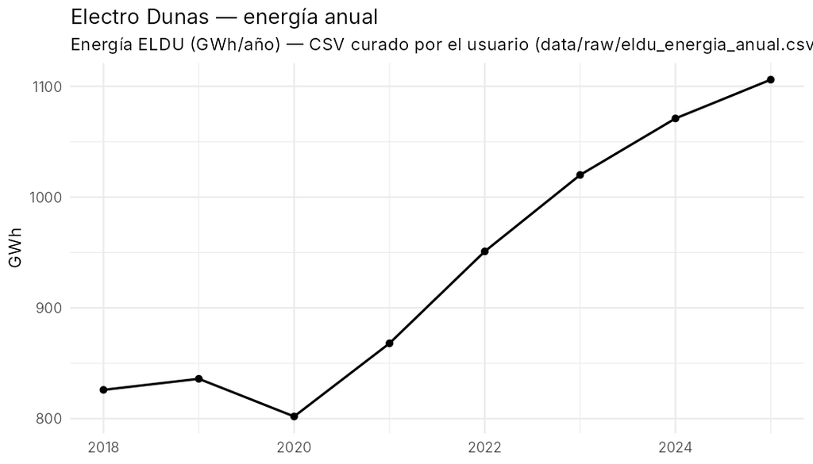

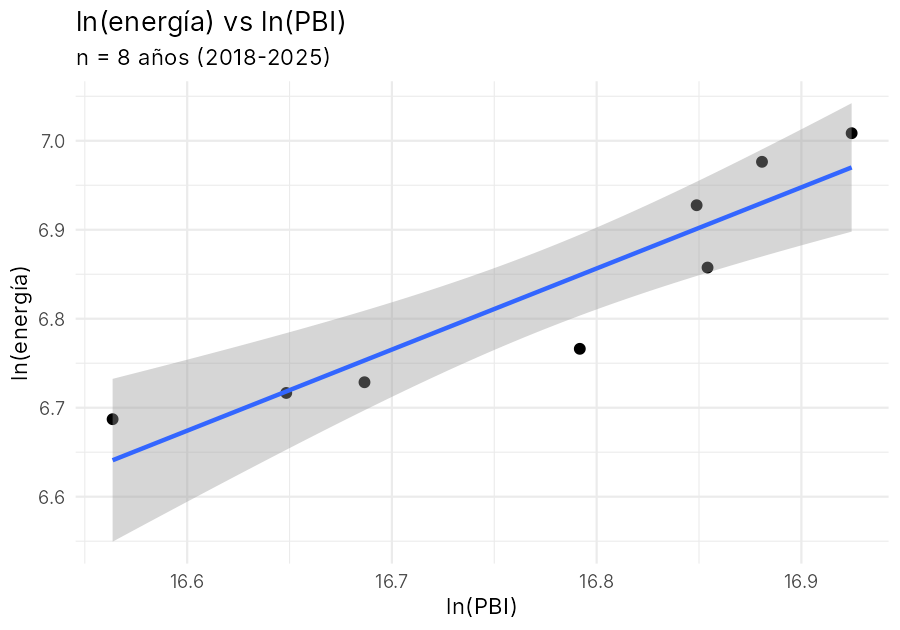

# Modelo y resultados

## Especificación

```
  Q = clientes x (energia por cliente)
  ln(Q/clientes) = a + eta*ln(VAB) + d*t        <- de aqui sale eta
  g_clientes                                     <- supuesto explicito
```

El método reportado **corresponde al n disponible** (n = 8): no se fuerza un ARDL/ECM.

## Raíz unitaria

- `ln_q`: omitido: n=8 < 12
- `ln_y`: omitido: n=8 < 12
- `ln_qc`: omitido: n=8 < 12

## Estimaciones

| Bloque | Rol | Método | η | EE (HAC) | IC95 inf | IC95 sup | p | n | R² |
| --- | --- | --- | --- | --- | --- | --- | --- | --- | --- |
| energia_por_cliente | corroboracion | OLS log-log con tendencia | 0.411 | 0.139 | 0.053 | 0.770 | 0.032 | 8 | 0.805 |
| energia_total | comparacion | OLS log-log con tendencia | 0.400 | 0.164 | -0.023 | 0.823 | 0.059 | 8 | 0.938 |
| energia_por_cliente | corroboracion | OLS log-log sin tendencia | 0.475 | 0.061 | 0.327 | 0.624 | 0.000 | 8 | 0.800 |
| energia_total | comparacion | OLS log-log sin tendencia | 0.912 | 0.154 | 0.536 | 1.288 | 0.001 | 8 | 0.854 |
| energia_por_cliente | PRINCIPAL | Regresión en diferencias | 0.320 | 0.082 | 0.110 | 0.529 | 0.011 | 7 | 0.508 |
| energia_total | comparacion | Regresión en diferencias | 0.315 | 0.085 | 0.096 | 0.535 | 0.014 | 7 | 0.510 |
| volumen_alt | robustez | Regresión en diferencias | 0.309 | 0.043 | 0.199 | 0.419 | 0.001 | 7 | 0.824 |
| ex_shock | robustez | Regresión en diferencias | 0.204 | 0.101 | -0.117 | 0.525 | 0.137 | 5 | 0.232 |
| driver_nacional | robustez | Regresión en diferencias | 0.437 | 0.094 | 0.196 | 0.677 | 0.006 | 7 | 0.526 |

Colinealidad ln(ingreso)↔︎tendencia: cor = 0.873, VIF = 4.2.

**ECM:** no intentado: n=8 < 15

## Diagnósticos

| modelo | r2 | adj_r2 | df_residual | durbin_watson | dw_p | breusch_godfrey | bg_p |
| --- | --- | --- | --- | --- | --- | --- | --- |
| OLS log-log con tendencia (por_cliente) | 0.805 | 0.726 | 5 | 1.128 | 0.032 | 1.043 | 0.307 |
| diferencias (por_cliente) | 0.508 | 0.409 | 5 | 1.107 | 0.140 | 1.151 | 0.283 |

**Estabilidad (leave-one-out):** η se mueve en [0.146, 0.532] al excluir un año; el más influyente es **2021** (Δη = 0.212).

## Robustez

- **volumen_alt**: η = 0.309 (IC95 0.199 a 0.419)
- **ex_shock**: η = 0.204 (IC95 -0.117 a 0.525)
- **driver_nacional**: η = 0.437 (IC95 0.196 a 0.677)

*(`ex_shock` excluye 2020 y 2021.)*

## Validación out-of-sample

omitida: n=8 < 12

# Proyección de volúmenes

Regla: `Q_{t+1} = Q_t * (1 + g_clientes) * (1 + eta * g_ingreso)`, desde Q(2025) = 1106.0 GWh hasta FY2035.

- Escenarios de ingreso: **SUPUESTO (no se proveyó data/raw/escenarios.csv): base=3.0%, optimista=4.5%, pesimista=1.5%**
- Crecimiento de clientes: **SUPUESTO: se sostiene el CAGR histórico de clientes, 2.65%/año (2018-2025)**

> ⚠️ Los crecimientos del ingreso son un **SUPUESTO** (no se proveyó `escenarios.csv`).

> ⚠️ Sostener el ritmo de conexiones hasta FY2035 es **el supuesto más fuerte de toda la proyección** y mueve el resultado más que η. Es una decisión del comité: se cambia en `CFG$clientes` (`g_override`, o `taper_to`/`taper_years` para que converja a una tasa menor).

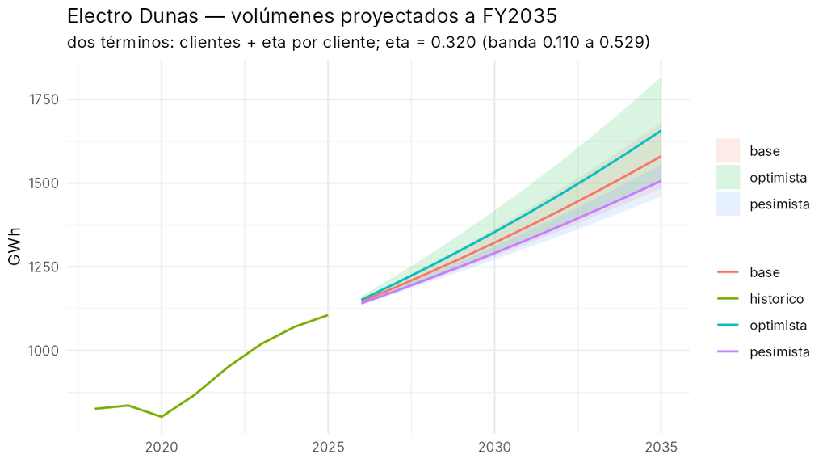

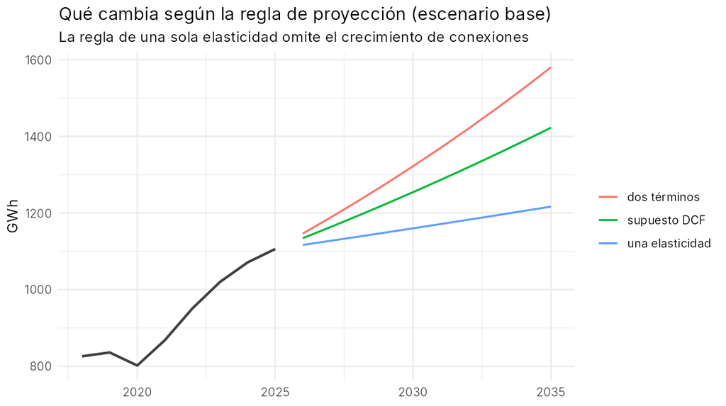

**Qué cambia según la regla (escenario base):**

| Regla | CAGR %/año | GWh FY2035 |
| --- | --- | --- |
| dos terminos (clientes + eta por cliente) | 3.63 | 1580.3 |
| una sola elasticidad, sin clientes | 0.96 | 1216.7 |
| supuesto DCF vigente (0.85) | 2.55 | 1422.7 |
| observado historico | 4.17 | NA |

**Volúmenes anuales con banda (banda = intervalo de η):**

| Escenario | Año | g ingreso | g clientes | GWh central | GWh inf | GWh sup |
| --- | --- | --- | --- | --- | --- | --- |
| base | 2026 | 3.0% | 2.65% | 1146.2 | 1139.0 | 1153.3 |
| base | 2027 | 3.0% | 2.65% | 1187.8 | 1173.1 | 1202.7 |
| base | 2028 | 3.0% | 2.65% | 1231.0 | 1208.1 | 1254.1 |
| base | 2029 | 3.0% | 2.65% | 1275.7 | 1244.2 | 1307.8 |
| base | 2030 | 3.0% | 2.65% | 1322.0 | 1281.3 | 1363.8 |
| base | 2031 | 3.0% | 2.65% | 1370.1 | 1319.6 | 1422.1 |
| base | 2032 | 3.0% | 2.65% | 1419.8 | 1359.0 | 1483.0 |
| base | 2033 | 3.0% | 2.65% | 1471.4 | 1399.6 | 1546.4 |
| base | 2034 | 3.0% | 2.65% | 1524.9 | 1441.4 | 1612.6 |
| base | 2035 | 3.0% | 2.65% | 1580.3 | 1484.5 | 1681.6 |
| optimista | 2026 | 4.5% | 2.65% | 1151.6 | 1140.9 | 1162.3 |
| optimista | 2027 | 4.5% | 2.65% | 1199.1 | 1176.9 | 1221.5 |
| optimista | 2028 | 4.5% | 2.65% | 1248.6 | 1214.0 | 1283.8 |
| optimista | 2029 | 4.5% | 2.65% | 1300.1 | 1252.4 | 1349.2 |
| optimista | 2030 | 4.5% | 2.65% | 1353.7 | 1291.9 | 1417.9 |
| optimista | 2031 | 4.5% | 2.65% | 1409.6 | 1332.7 | 1490.1 |
| optimista | 2032 | 4.5% | 2.65% | 1467.7 | 1374.7 | 1566.0 |
| optimista | 2033 | 4.5% | 2.65% | 1528.2 | 1418.1 | 1645.8 |
| optimista | 2034 | 4.5% | 2.65% | 1591.3 | 1462.8 | 1729.6 |
| optimista | 2035 | 4.5% | 2.65% | 1656.9 | 1509.0 | 1817.7 |
| pesimista | 2026 | 1.5% | 2.65% | 1140.7 | 1137.2 | 1144.3 |
| pesimista | 2027 | 1.5% | 2.65% | 1176.6 | 1169.2 | 1183.9 |
| pesimista | 2028 | 1.5% | 2.65% | 1213.5 | 1202.2 | 1225.0 |
| pesimista | 2029 | 1.5% | 2.65% | 1251.6 | 1236.0 | 1267.4 |
| pesimista | 2030 | 1.5% | 2.65% | 1290.9 | 1270.9 | 1311.3 |
| pesimista | 2031 | 1.5% | 2.65% | 1331.5 | 1306.7 | 1356.7 |
| pesimista | 2032 | 1.5% | 2.65% | 1373.3 | 1343.5 | 1403.7 |
| pesimista | 2033 | 1.5% | 2.65% | 1416.4 | 1381.3 | 1452.3 |
| pesimista | 2034 | 1.5% | 2.65% | 1460.9 | 1420.3 | 1502.6 |
| pesimista | 2035 | 1.5% | 2.65% | 1506.8 | 1460.3 | 1554.7 |

**Reparto BT/MT/libres:** no se realizó. Las ventas por segmento existen sólo desde 2022 (4 años), que no alcanzan para estimar elasticidades separadas, y los pesos de ingreso no están en la data. **No se inventan**: si el comité los necesita, se cargan en `CFG$segment_weights` y se re-corre.

# Limitaciones (honestas)

1. **Tamaño muestral: n = 8.** Es la restricción que manda. Por debajo de 12 no hay grados de libertad para ADF, cointegración, ECM ni validación out-of-sample, y todos se omitieron en vez de forzarse. Los IC son anchos por construcción.
2. **Frecuencia anual.** El SICOM mensual de Osinergmin requiere solicitud formal y no se usó. Toda la dinámica intra-anual (estacionalidad del agro de Ica, efecto tarifario, rezagos) es invisible.
3. **El COVID pesa demasiado.** Excluyendo 2020 y 2021, η pasa de 0.320 a 0.204. Con n=8, dos observaciones extremas aportan buena parte de la identificación: el rango reportado es más creíble que cualquier punto.
4. **Los IC 95% son optimistas.** Los errores HAC/Newey-West son asintóticos: con n de un dígito su cobertura real es menor que el 95% nominal. El intervalo de muestreo que aparece en la tabla subestima la incertidumbre, y es otra razón para leer η como rango y no como punto.
5. **Crecimiento de clientes no modelado.** Entra como supuesto, no como estimación: las conexiones responden a política de expansión y demografía, no al PBI. Dado que explican la mayor parte del crecimiento del volumen, el resultado de la proyección depende más de ese supuesto que de η.
6. **Sin desagregado BT/MT/libres.** Las ventas por segmento arrancan en 2022 (4 años). El objetivo original —reemplazar 0.8 BT y 0.9 MT por *dos* elasticidades estimadas— **no es alcanzable con esta data**: sólo se puede entregar una η agregada sobre el consumo por cliente.
7. **El driver regional tiene su propio ruido.** El VAB de Ica está dominado por minería, manufactura y agroexportación, cuyo ciclo no coincide con el consumo eléctrico del padrón de ELDU: en 2023 el VAB cayó mientras la energía creció. Los últimos años son además preliminares (P/) y estimados (E/) y se revisan.
8. **Sin control climático.** Los índices ENSO no se incorporaron (quedaron fuera de alcance por pedido), así que un año de El Niño entra como ruido en el residuo — relevante en Ica, donde el agro manda.
9. **Precisión de la serie 2018-2021.** Según la columna `fuente` del insumo, esos años se leyeron de un **gráfico** de la Memoria 2025, no de un cuadro. Los años 2022-2025 vienen de cuadros. La precisión de los primeros es menor.
10. **Alcance.** Modelo de alto nivel para una valorización DCF de comité, no una tesis econométrica. El objetivo era reemplazar η *a dedo* por una estimación trazable **con su incertidumbre**, y el hallazgo principal es estructural (falta el término de conexiones), no de calibración. Cuando llegue el SICOM mensual, migrar al pipeline ARDL/ECM completo.

# Reproducibilidad

- Semilla: `20261007`
- `output/sessionInfo.txt` — versiones exactas de R y paquetes.
- `data/raw/SOURCES.md` — procedencia (archivo, descripción, SHA256) de cada insumo.
- `output/fetch_log.txt` — log completo de la corrida.
- Ejecutar todo con: `Rscript run_all.R`